# Mock analysis of the output parameters

In this notebook, we look at the mock results from the run with AGN (SKIRTOR and Fritz) to see how much of the results depends in the grid of parameters. First, we import the Python packages.

```python
%pylab
```

```
Using matplotlib backend: Qt5Agg
```

```python
import matplotlib.colors as colors

import astropy.units as u
from astropy.table import Table, join, vstack
```

We read the clean results from the SKIRTOR and Fritz setups

```python
ModelS = Table.read('../Data/Final/CIGALEOutputs/Cleanresults_SK.fits', format='fits')
ModelF = Table.read('../Data/Final/CIGALEOutputs/Cleanresults_Fr.fits', format='fits')
```

## Join mock results

We stack the results from the mock observations to compared with the clean results for the SKIRTOR and Fritz setups.

```python
INTERIM_FOLDER = '../Data/Interim/CIGALEOutputs_mock/'

# Fritz model
Mocks_Fr = Table()
for grp in range(1, 11):
    model = Table.read(INTERIM_FOLDER+'FrAGN/results_mock'+str(grp)+'.fits',
                       format='fits')
    Mocks_Fr = vstack([model, Mocks_Fr])

# SKIRTOR model
Mocks_SK = Table()
for grp in range(1, 11):
    model = Table.read(INTERIM_FOLDER+'SKAGN/results_mock'+str(grp)+'.fits',
                       format='fits')
    Mocks_SK = vstack([model, Mocks_SK])
```

We rename the Fritz models as $i=90-\psi$ (with $\psi$ the angle between the equator to the pole of the system) and the thermal (dust) luminosity to compare with SKIRTOR model.

```python
Mocks_Fr.rename_column('bayes.agn.psy', 'bayes.agn.i')
Mocks_Fr.rename_column('bayes.agn.psy_err', 'bayes.agn.i_err')
Mocks_Fr.rename_column('bayes.agn.therm_luminosity', 'bayes.agn.dust_luminosity')
Mocks_Fr.rename_column('bayes.agn.therm_luminosity_err',
                   'bayes.agn.dust_luminosity_err')
Mocks_Fr['bayes.agn.i'] = 90-Mocks_Fr['bayes.agn.i']
```

Finally, we join both models with their mocks counterparts

```python
Both_SK = join(ModelS, Mocks_SK, keys='id')
Both_Fr = join(ModelF, Mocks_Fr, keys='id')
```

This numbers should be the same as the one in Table 3.

```python
print('The number of mock galaxies are %d for SKIRTOR and %d for Fritz'
      %(len(Both_SK), len(Both_Fr)))
```

```
The number of mock galaxies are 7992 for SKIRTOR and 8416 for Fritz
```

We transform luminosities from W to solar luminosities. In addition, we reformat some parameters in log units, useful for the plots.

```python
for modl in [Both_Fr, Both_SK]:
    for kisd in ['bayes.agn.luminosity', 'bayes.agn.disk_luminosity', 'bayes.agn.accretion_power',
                 'bayes.agn.dust_luminosity', 'bayes.dust.luminosity']:
        for sub in ['_1', '_2']:
            modl[kisd+sub] = (modl[kisd+sub]).to(u.solLum)
            modl[kisd+'_err'+sub] = (modl[kisd+'_err'+sub]).to(u.solLum)

    for asdf in ['bayes.agn.disk_luminosity', 'bayes.agn.accretion_power',
                 'bayes.agn.luminosity', 'bayes.agn.dust_luminosity',
                 'bayes.dust.luminosity', 'bayes.sfh.sfr',
                 'bayes.stellar.m_star', 'bayes.sfh.tau_main']:
        for sub in ['_1', '_2']:
            modl[asdf+'_err'+sub] = modl[asdf+'_err'+sub]/(modl[asdf+sub] * np.log(10))
            modl[asdf+sub] = np.log10(modl[asdf+sub])
```

## Check of $\chi_{\rm{red}}^{2}$ distributions

We check how the $\chi_{\rm{red}}^{2}$ have changed between the mock and the estimated values

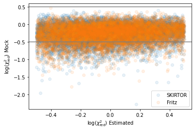

```python
%matplotlib inline
plt.scatter(np.log10(Both_SK['best.reduced_chi_square_1']),
            np.log10(Both_SK['best.reduced_chi_square_2']), alpha=0.1, label='SKIRTOR')
plt.scatter(np.log10(Both_Fr['best.reduced_chi_square_1']),
            np.log10(Both_Fr['best.reduced_chi_square_2']), alpha=0.1, label='Fritz')
plt.axhline(y=0.5, c='gray')
plt.axhline(y=-0.5, c='gray')
plt.xlabel(r'$\log(\chi^2_{\rm{red}})$ Estimated')
plt.ylabel(r'$\log(\chi^2_{\rm{red}})$ Mock')
plt.legend()
```

## Comparison between estimated and mock values

We present the plots between the estimated and mock values for a set of physical parameters important for this work. We define list to define the limits and labels for the different subplots.

```python
list_part = ['agn.i', 'agn.fracAGN', 'agn.disk_luminosity', 'agn.EBV',
             'attenuation.E_BVs', 'sfh.tau_main', 'sfh.sfr',
             'agn.accretion_power', 'stellar.m_star', 'dust.luminosity']
#              'sfh.age', 'agn.luminosity', 'agn.dust_luminosity' ]
ParamLabel = ['View. Angle', r'$f_{\rm{AGN}}$', r'$\rm{L}_{\rm{AGN}}^{\rm{disc}}$',
              r'Polar-dust E(B-V)', 'E(B-V)', r'$\tau_{\rm{main}}$', 'SFR',
              'AGN accre. power',  r'Stellar Mass',
              r'$\rm{L}_{\rm{dust}}$', '']
ParamRange = [[0, 90], [0.05, 0.95], [7, 12], [0, 1],
              [0.088, 0.352], [1.65, 3.7], [-3, 3],
              [8, 13], [8, 12], [8, 12]]
ParamUnit = ['[degrees]', '[Fraction]', r'[$\log$(L$_{\odot}$)]', '[mag]',
             '[mag]', r'[$\log$(Myr)]', r'[$\log$(M$_{\odot}$/yr)]',
             r'[$\log$(L$_{\odot}$)]', r'[$\log$(M$_{\odot}$)]', r'[$\log$(L$_{\odot}$)]']
Particks = [[0, 25, 45, 65, 90], [0.25, 0.5, 0.75], [8, 10, 12], [0, 0.4, 0.8],
            [0.1, 0.2, 0.3], [2, 2.5, 3, 3.5], [-2, 0, 2],
            [8, 10, 12], [8, 10, 12], [8, 10, 12]]
LocErr = [[par[0] + ((par[1]-par[0])*0.7), par[0] + ((par[1]-par[0])*0.3)]
          for i_par, par in enumerate(ParamRange)]
```

We truncate the colormap to clearly see the differences

```python
cmap = plt.get_cmap('YlOrBr')


def truncate_colormap(colormap, minval=0.0, maxval=1.0, nspa=100):
    """Function found on stackoverflow.com: how-to-extract-a-subset-of-a-colormap-as-
    a-new-colormap-in-matplotlib"""
    new_colormap = colors.LinearSegmentedColormap.from_list(
        'trunc({n},{a:.2f},{b:.2f})'.format(n=colormap.name, a=minval, b=maxval),
        colormap(np.linspace(minval, maxval, nspa)))
    return new_colormap


new_cmap = truncate_colormap(cmap, 0.1, 0.95)
```

##### For SKIRTOR

```python
%matplotlib

# with plt.style.context('seaborn-talk'):
with plt.style.context('seaborn-paper'):
    plt.rcParams.update({'font.size': 11})
    plt.rcParams.update({'axes.labelsize': 11})
    plt.rcParams.update({'legend.fontsize': 10})
    plt.rcParams.update({'ytick.labelsize': 10})
    plt.rcParams.update({'xtick.labelsize': 10})
    fig, axs = plt.subplots(3, 3, figsize=(14.06, 7))
    for i_par, phyp in enumerate(list_part[:-1]):
        ax = axs.ravel()[i_par]
        paramet = 'bayes.'+phyp
        bins_total = np.linspace(ParamRange[i_par][0],
                                 ParamRange[i_par][1], 26)
        hist_par, _, _ = np.histogram2d(Both_SK[paramet+'_1'],
                                        Both_SK[paramet+'_2'],
                                        bins=(bins_total, bins_total))
        hist_par[hist_par <= 1.0] = np.nan
        valper = hist_par.T/len(Both_SK) * 100
        ax.scatter(Both_SK[paramet+'_1'],
                   Both_SK[paramet+'_2'], c='Orange', s=1)
        mape = ax.imshow(valper, interpolation='None', origin='lower', cmap=new_cmap,
                         extent=[bins_total.min(), bins_total.max(),
                                 bins_total.min(), bins_total.max()], zorder=1,
                         #                          vmax=2)
                         vmax=np.nanpercentile(valper, 98))
        clb = fig.colorbar(mape, ax=ax, pad=0, fraction=0.0476)
        clb.ax.set_title('%')
        ax.plot([bins_total.min(), bins_total.max()],
                [bins_total.min(), bins_total.max()], c='k', ls=':')
        ax.set_xlim(bins_total.min(), bins_total.max())
        ax.set_ylim(bins_total.min(), bins_total.max())
        ax.set_xticks(Particks[i_par])
        ax.set_yticks(Particks[i_par])
        ax.set_title(ParamLabel[i_par])
        ax.set_ylabel('Mock value '+ParamUnit[i_par])
        ax.set_xlabel('Estimated value '+ParamUnit[i_par])
        Xerr = np.median(Both_Fr[paramet+'_err_1'])
        Yerr = np.median(Both_Fr[paramet+'_err_2'])
        print(ParamLabel[i_par], 'Median error ', Yerr)
        ax.errorbar(LocErr[i_par][0], LocErr[i_par][1],
                    xerr=Xerr, yerr=Yerr, c='gray')
    plt.subplots_adjust(wspace=0.0, left=0.1, right=0.9,
                        top=0.98, bottom=0.02, hspace=0.45)
    plt.savefig('../Figures/B1.pdf', dpi=300, bbox_inches='tight')  # For Paper
#     plt.savefig('../Talk_Figures/B1.png', dpi=300, bbox_inches='tight') ## For Presentation
```

```
Using matplotlib backend: Qt5Agg
```

```
View. Angle Median error  15.573180241055931
$f_{\rm{AGN}}$ Median error  0.13303726743588146
$\rm{L}_{\rm{AGN}}^{\rm{disc}}$ Median error  0.15260731437319294
Polar-dust E(B-V) Median error  0.2741983026998453
E(B-V) Median error  0.05425392144368513
$\tau_{\rm{main}}$ Median error  0.29930739567563475
SFR Median error  0.20953873847727084
AGN accre. power Median error  0.10215998591755218
Stellar Mass Median error  0.17965602116109908
```

##### For Fritz model

```python
%matplotlib

# with plt.style.context('seaborn-talk'):
with plt.style.context('seaborn-paper'):
    plt.rcParams.update({'font.size': 11})
    plt.rcParams.update({'axes.labelsize': 11})
    plt.rcParams.update({'legend.fontsize': 10})
    plt.rcParams.update({'ytick.labelsize': 10})
    plt.rcParams.update({'xtick.labelsize': 10})
    fig, axs = plt.subplots(3, 3, figsize=(14.06, 7))
    for i_par, phyp in enumerate(list_part[:-1]):
        ax = axs.ravel()[i_par]
        paramet = 'bayes.'+phyp
        bins_total = np.linspace(ParamRange[i_par][0],
                                 ParamRange[i_par][1], 26)
        hist_par, _, _ = np.histogram2d(Both_Fr[paramet+'_1'],
                                        Both_Fr[paramet+'_2'],
                                        bins=(bins_total, bins_total))
        hist_par[hist_par <= 1.0] = np.nan
        valper = hist_par.T/len(Both_Fr) * 100
        ax.scatter(Both_Fr[paramet+'_1'],
                   Both_Fr[paramet+'_2'], c='Orange', s=1)
        mape = ax.imshow(valper, interpolation='None', origin='lower', cmap=new_cmap,
                         extent=[bins_total.min(), bins_total.max(),
                                 bins_total.min(), bins_total.max()], zorder=1,
                         #                          vmax=2)
                         vmax=np.nanpercentile(valper, 98))
        clb = fig.colorbar(mape, ax=ax, pad=0, fraction=0.0476)
        clb.ax.set_title('%')
        ax.plot([bins_total.min(), bins_total.max()],
                [bins_total.min(), bins_total.max()], c='k', ls=':')
        ax.set_xlim(bins_total.min(), bins_total.max())
        ax.set_ylim(bins_total.min(), bins_total.max())
        ax.set_xticks(Particks[i_par])
        ax.set_yticks(Particks[i_par])
        ax.set_title(ParamLabel[i_par])
        ax.set_ylabel('Mock value '+ParamUnit[i_par])
        ax.set_xlabel('Estimated value '+ParamUnit[i_par])
        Xerr = np.median(Both_Fr[paramet+'_err_1'])
        Yerr = np.median(Both_Fr[paramet+'_err_2'])
        print(ParamLabel[i_par], 'Median error ', Yerr)
        ax.errorbar(LocErr[i_par][0], LocErr[i_par][1],
                    xerr=Xerr, yerr=Yerr, c='gray')
    plt.subplots_adjust(wspace=0.0, left=0.1, right=0.9,
                        top=0.98, bottom=0.02, hspace=0.45)
    plt.savefig('../Figures/B1_Alt.pdf', dpi=300, bbox_inches='tight')  # For Paper
#     plt.savefig('../Talk_Figures/B1_Alt.png', dpi=300, bbox_inches='tight') ## For Presentation
```

```
Using matplotlib backend: Qt5Agg
```

```
View. Angle Median error  15.573180241055931
$f_{\rm{AGN}}$ Median error  0.13303726743588146
$\rm{L}_{\rm{AGN}}^{\rm{disc}}$ Median error  0.15260731437319294
Polar-dust E(B-V) Median error  0.2741983026998453
E(B-V) Median error  0.05425392144368513
$\tau_{\rm{main}}$ Median error  0.29930739567563475
SFR Median error  0.20953873847727084
AGN accre. power Median error  0.10215998591755218
Stellar Mass Median error  0.17965602116109908
```

```python
%load_ext watermark
%watermark -a "Andres Ramos" -d -v -m
print('Specific Python packages')
%watermark -iv -w --packages astroquery
```

```
Author: Andres Ramos

Python implementation: CPython
Python version       : 3.8.3
IPython version      : 7.16.1

Compiler    : GCC 7.3.0
OS          : Linux
Release     : 3.10.0-1160.25.1.el7.x86_64
Machine     : x86_64
Processor   : x86_64
CPU cores   : 8
Architecture: 64bit

Specific Python packages
astroquery: 0.4.1

json      : 2.0.9
numpy     : 1.19.5
autopep8  : 1.5.7
re        : 2.2.1
matplotlib: 3.2.2
sys       : 3.8.3 (default, Jul  2 2020, 16:21:59)
[GCC 7.3.0]
astropy   : 4.2
logging   : 0.5.1.2

Watermark: 2.1.0
```